# Assignment #4

# Produce a list of top 20 bigrams

#Text compiler

```r
###
# Define function to loop through each text file
###

create_article_text <- function(row_value) {

  #row_value is the single argument that is passed to the function
  # Take each row of the dataframe
  temp <- final_index %>%
    slice(row_value)

  # Store the filename for  use in constructing articles dataframe
  temp_filename <- temp$filename

  # Create a dataframe by reading in lines of a given textfile
  # Add a filename column
  articles_df_temp <- read_lines(temp$filepath) %>%
    as_tibble() %>%
    mutate(filename = temp_filename)

  # Bind results to master articles_df
  # <<- returns to global environment
  articles_df <<- articles_df %>%
    bind_rows(articles_df_temp)
}

###
# Create elements needed to run function
###

# Create empty tibble to store results
articles_df <- tibble()
#running once to test
#create_article_text(2)
# Create an array of numbers to loop through, from 1 to the number of rows in our index dataframe
row_values <- 1:nrow(final_index)

###
# Execute function using lapply
# This loops through each row of the dataframe and append results to master file
###

lapply(row_values, create_article_text)
```

[output not shown]

[output cut: 2692 more lines]

[output not shown]

```r
###
# Clean up articles_df and join to index dataframe
###

articles_df <- articles_df %>%
  select(filename, sentence=value) %>%
  inner_join(final_index)
View(articles_df)
#After viewing articles_df, I see the first line from the index that I don't need. Cutting it

articles_df <- articles_df %>%
  slice(-1) |>
  #gets rid of blank rows
    filter(trimws(sentence) != "") %>%
  slice(-1)

write.csv(articles_df, "../final_summary/assets/extracted_text/AIhealth.csv")
# Now we get the data frame with one row per sentence
```

#Tokenize the data, one word per row

```r
library(tidyverse)
library(tidytext)
library(janitor)
library(lubridate)
library(jsonlite)
library(rio)
library(quanteda)
articles_df <- articles_df %>% mutate(text = str_squish(sentence))
articles_df <- articles_df %>%
  mutate(text = tolower(text)) |>
  mutate(text = str_replace_all(text, "wiki|Copyright|All Rights Reserved|enwikipediaorg|load-date|news service|publication-type|publication type|daily eastern|eastern  news|[0-9.]|identifier /keyword|twitter\\.", ""))

data_use <- str_replace_all(articles_df$text, "- ", "")
data_tok <- tibble(data_use,)
head(data_tok) # The name of the column is data_use
```

```
## # A tibble: 6 × 1
##   data_use
##   <chr>
## 1 this new program builds on the success of techstars equitech, a three-cohort …
## 2 techstars ai health baltimore will serve as techstars new flagship health car…
## 3 copyright ©  bridgetower media all rights reserved
## 4 ai) tools on thursday aiming to support health care organizations through med…
## 5 the announcement detailed how each tool will improve workflow for busy health…
## 6 the ai imaging tool, developed in collaboration with partners like providence…
```

```r
# create bigram
data_tok_bi <- data_tok  %>%
  unnest_tokens(bigram, data_use, token="ngrams", n=2)
#View(data_tok_bi)

data_tok_bi_count <- data_tok_bi %>%
  separate(bigram, c("word1", "word2"), sep = " ")%>% # Seperate the words
  filter(!word1 %in% stop_words$word) %>%
  filter(!word2 %in% stop_words$word) %>% # remove stopwords
  filter(!is.na(word1)) %>%
  filter(!is.na(word2)) %>%  # remove NAs
  count(word1, word2, sort = TRUE)
data_tok_bi_count
```

```
## # A tibble: 19,955 × 3
##    word1      word2            n
##    <chr>      <chr>        <int>
##  1 health     care           303
##  2 artificial intelligence   178
##  3 mental     health         147
##  4 generative ai              67
##  5 health     systems         56
##  6 ai         tools           52
##  7 ai         systems         43
##  8 vice       president       38
##  9 ai         technology      37
## 10 health     system          37
## # ℹ 19,945 more rows
```

```r
# top 20 bigrams
data_tok_bi_count_20  <- data_tok_bi_count  %>%
  slice_max(n, n=20)
data_tok_bi_count_20
```

```
## # A tibble: 20 × 3
##    word1      word2            n
##    <chr>      <chr>        <int>
##  1 health     care           303
##  2 artificial intelligence   178
##  3 mental     health         147
##  4 generative ai              67
##  5 health     systems         56
##  6 ai         tools           52
##  7 ai         systems         43
##  8 vice       president       38
##  9 ai         technology      37
## 10 health     system          37
## 11 ai         models          36
## 12 social     media           36
## 13 submit     search          36
## 14 patient    care            32
## 15 machine    learning        31
## 16 ai         powered         29
## 17 climate    change          28
## 18 cross      country         28
## 19 associate  professor       27
## 20 search     bar             26
```

#Create a ggplot chart showing the top 20 bigrams

```r
library(ggplot2)
library(forcats)

# combine the "word1" and "word2" into one column, and create a new data frame
plot_bi <- data.frame(word= paste(data_tok_bi_count_20$word1, data_tok_bi_count_20$word2), n = data_tok_bi_count_20$n)
head(plot_bi)
```

```
##                      word   n
## 1             health care 303
## 2 artificial intelligence 178
## 3           mental health 147
## 4           generative ai  67
## 5          health systems  56
## 6                ai tools  52
```

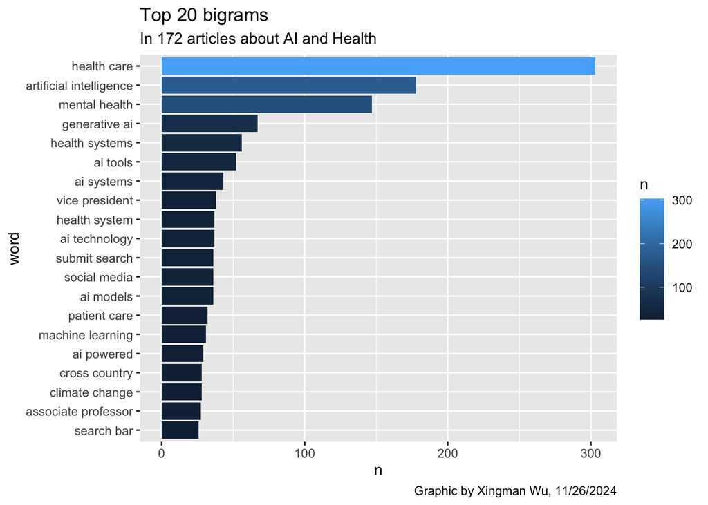

```r
View(plot_bi)

plot_bi  %>%
  ggplot(aes(n, fct_reorder(word, n, .desc = F), fill = n)) +
  geom_col() +
  labs(y = NULL) +
   labs(title = "Top 20 bigrams",
       subtitle = "In 172 articles about AI and Health",
       caption = "Graphic by Xingman Wu, 11/26/2024",
       y="word",
       x="n")
```

## Findings

The chart highlights the 20 most frequent bigrams in the articles. “Health care” is the most common, followed by “artificial intelligence” and “mental health.” Other key terms include “generative AI,” “health systems,” and “AI tools,” reflecting a strong emphasis on AI’s role in healthcare and mental health. Phrases like “social media,” and “patient care” suggest specific applications or contexts for AI. Additionally, “vice president” and “climate change” point out other dimensions of the articles. For the next step, I would like to discuss the bigrams along with the results of the topic model and sentiment analysis.

## Continuing…

Before the presentation, I will conduct the topic model analysis, co-occurrence analysis, sentimental analysis based on the whole data set and also the data grouped by months.

## topic modeling analysis

```r
## install and load packages
#install.packages("tm")
#install.packages("topicmodels")
#install.packages("reshape2")
#install.packages("ggplot2")
#install.packages("wordcloud")
#install.packages("pals")
#install.packages("SnowballC")
#install.packages("lda")
#install.packages("ldatuning")
#install.packages("kableExtra")
#install.packages("DT")
#install.packages("flextable")
library(tm)
library(NLP)
library(topicmodels)
library(reshape2)
library(ggplot2)
library(wordcloud)
library(pals)
library(SnowballC)
library(lda)
library(ldatuning)
library(kableExtra)
library(DT)
library(flextable)
# install klippy for copy-to-clipboard button in code chunks
#install.packages("remotes")
#remotes::install_github("rlesur/klippy")
library(remotes)
library(klippy)
library(dplyr)
library(tidyr)
library(tibble)

# set options
options(stringsAsFactors = F)         # no automatic data transformation
options("scipen" = 100, "digits" = 4) # suppress math annotation

# activate klippy for copy-to-clipboard button
klippy::klippy()
```

### Process into corpus object

```r
textdata <- articles_df %>%
  select(filename, sentence, month) %>%
  as.data.frame() %>%
  rename(doc_id = filename, text= sentence)
head(textdata)
```

```
##               doc_id
## 1 AI_extracted_1.txt
## 2 AI_extracted_1.txt
## 3 AI_extracted_1.txt
## 4 AI_extracted_2.txt
## 5 AI_extracted_2.txt
## 6 AI_extracted_2.txt
##                                                                                                                                                                                                                                                                                                          …
## 1                                                                                                            This new program builds on the success of Techstars Equitech, a three-cohort series in partnership with UpSurge Baltimore that concluded in May. In its capacity as Baltimores technology ec…
## 2 Techstars AI Health Baltimore will serve as Techstars new flagship health care accelerator. Adam Phillips, the former managing director of Techstars Equitech, will lead the 13-week program focused on supporting entrepreneurs leading healthtech, medtech, and biotech startups. Startups will recei…
## 3                                                                                                                                                                                                                                                                                                        …
## 4                                                                                                                                                                                                                                                                                AI) tools on Thursday ai…
## 5                                                                                                                                                                                                                                                                                                        …
## 6                                               The AI imaging tool, developed in collaboration with partners like Providence and Paige.ai, enables health care organizations to integrate and analyze various data types beyond just text, including medical images, clinical records and genomic data. …
##   month
## 1     8
## 2     8
## 3     8
## 4    10
## 5    10
## 6    10
```

```r
# load stopwords
english_stopwords <- readLines("https://slcladal.github.io/resources/stopwords_en.txt", encoding = "UTF-8")
# create corpus object
corpus <- Corpus(DataframeSource(textdata))
# Preprocessing chain
processedCorpus <- tm_map(corpus, content_transformer(tolower))
processedCorpus <- tm_map(processedCorpus, removeWords, english_stopwords)
processedCorpus <- tm_map(processedCorpus, removePunctuation, preserve_intra_word_dashes = TRUE)
processedCorpus <- tm_map(processedCorpus, removeNumbers)
processedCorpus <- tm_map(processedCorpus, stemDocument, language = "en")
processedCorpus <- tm_map(processedCorpus, stripWhitespace)
```

```r
#DTM: rows correspond to the documents in the corpus. Columns correspond to the terms in the documents. Cells correspond to the weights of the terms. (Girder)
# compute document term matrix with terms >= minimumFrequency
minimumFrequency <- 5
DTM <- DocumentTermMatrix(processedCorpus, control = list(bounds = list(global = c(minimumFrequency, Inf))))
# have a look at the number of documents and terms in the matrix
dim(DTM)
```

```
## [1] 4846 2331
```

```r
# due to vocabulary pruning, we have empty rows in our DTM
# LDA does not like this. So we remove those docs from the
# DTM and the metadata
sel_idx <- slam::row_sums(DTM) > 0
DTM <- DTM[sel_idx, ]
textdata <- textdata[sel_idx, ]
```

### Set K Value for number of topics

```r
# number of topics
# K <- 20
K <- 6
```

### Run LDA, Latent Dirichlet Allocation

```r
# set random number generator seed
set.seed(20777)
#Latent Dirichlet Allocation, LDA
topicModel2 <- LDA(DTM, K, method="Gibbs", control=list(iter = 500, verbose = 25, alpha = 0.2))
```

```
## K = 6; V = 2331; M = 4605
## Sampling 500 iterations!
## Iteration 25 ...
## Iteration 50 ...
## Iteration 75 ...
## Iteration 100 ...
## Iteration 125 ...
## Iteration 150 ...
## Iteration 175 ...
## Iteration 200 ...
## Iteration 225 ...
## Iteration 250 ...
## Iteration 275 ...
## Iteration 300 ...
## Iteration 325 ...
## Iteration 350 ...
## Iteration 375 ...
## Iteration 400 ...
## Iteration 425 ...
## Iteration 450 ...
## Iteration 475 ...
## Iteration 500 ...
## Gibbs sampling completed!
```

```r
tmResult <- posterior(topicModel2)
theta <- tmResult$topics
beta <- tmResult$terms
topicNames <- apply(terms(topicModel2, 10), 2, paste, collapse = " ")  # reset topicnames
```

```r
# Step 1: Check dimensions
n_theta <- nrow(theta)
n_textdata <- length(textdata$month)

cat("Number of rows in theta: ", n_theta, "\n")
```

```
## Number of rows in theta:  4605
```

```r
cat("Number of documents in textdata: ", n_textdata, "\n")
```

```
## Number of documents in textdata:  4605
```

```r
# Check if textdata contains all the documents in theta
common_ids <- intersect(rownames(theta), textdata$doc_id) # Assuming textdata has a 'doc_id' column

# Filter textdata to include only the documents present in theta
textdata_filtered <- textdata[textdata$doc_id %in% common_ids, ]

# Check dimensions after filtering
n_textdata_filtered <- nrow(textdata_filtered)
cat("Number of documents in filtered textdata: ", n_textdata_filtered, "\n")
```

```
## Number of documents in filtered textdata:  4605
```

```r
# Ensure the lengths match now
if (n_theta != n_textdata_filtered) {
  stop("The number of rows in 'theta' still does not match the length of 'textdata_filtered$month'.")
}

# Align rownames of theta with filtered textdata
theta_aligned <- theta[rownames(theta) %in% textdata_filtered$doc_id, ]

# Optional: Verify the order of documents
if (!all(rownames(theta_aligned) == textdata_filtered$doc_id)) {
  # If the order doesn't match, reorder one to match the other
  textdata_filtered <- textdata_filtered[match(rownames(theta_aligned), textdata_filtered$doc_id), ]
}

# Ensure they are now aligned and can be combined
if (!all(rownames(theta_aligned) == textdata_filtered$doc_id)) {
  stop("The document IDs still do not match. Please check the data alignment.")
}

# Step 2: Combine data
topic_data <- data.frame(theta_aligned, month = textdata_filtered$month)

# Step 3: Aggregate data
topic_proportion_per_month <- aggregate(. ~ month, data = topic_data, FUN = mean)


# get mean topic proportions per month
# topic_proportion_per_month <- aggregate(theta, by = list(decade = textdata$month), mean)
# set topic names to aggregated columns
colnames(topic_proportion_per_month)[2:(K+1)] <- topicNames
# reshape data frame
vizDataFrame <- melt(topic_proportion_per_month, id.vars = "month")
head(vizDataFrame)
```

```
##   month                                                  variable  value
## 1     1 patient human time doctor make imag medic tool peopl care 0.2555
## 2     2 patient human time doctor make imag medic tool peopl care 0.4051
## 3     3 patient human time doctor make imag medic tool peopl care 0.1811
## 4     4 patient human time doctor make imag medic tool peopl care 0.2122
## 5     5 patient human time doctor make imag medic tool peopl care 0.2268
## 6     6 patient human time doctor make imag medic tool peopl care 0.2350
```

#Examine topic names

```r
#enframe(): Converts a named list into a dataframe.
topics <- enframe(topicNames, name = "number", value = "text") %>%
  unnest(cols = c(text))

topics
```

```
## # A tibble: 6 × 2
##   number  text
##   <chr>   <chr>
## 1 Topic 1 patient human time doctor make imag medic tool peopl care
## 2 Topic 2 student univers school search professor communiti peopl scienc open r…
## 3 Topic 3 news eiu daili stori week eastern sport win soccer oct
## 4 Topic 4 data technolog system process develop digit privaci advanc govern pot…
## 5 Topic 5 health care patient medic system mental technolog intellig provid art…
## 6 Topic 6 busi compani year program grant furman small paladin includ million
```

### Review the topics and determine a 1-2 word label after reading the source documents.

```r
theta2 <- as.data.frame(theta)

library(stringr)


topic3 <- theta2 %>%
  rownames_to_column(var = "file") |> # putting the rownames into a new column called file
  mutate(file = str_remove(file, "^X"),  # Remove leading 'X'
         line = str_extract(file, "(?<=\\.txt)\\.\\d+")) |>   # Extract number after .txt
  mutate(file = str_remove(file, "\\.\\d+$")) |>
  rename(topic3 = '3') |> # looking at topic3
  top_n(20, topic3) |>
  arrange(desc(topic3)) |>
  select(file, line, topic3)

topic3 # Topic3 is not related to AI and health, so I deleted topic3
```

```
##                    file line topic3
## 1   AI_extracted_63.txt  .25 0.9970
## 2   AI_extracted_93.txt  .29 0.9970
## 3  AI_extracted_117.txt  .29 0.9970
## 4   AI_extracted_96.txt  .29 0.9969
## 5  AI_extracted_136.txt  .29 0.9939
## 6   AI_extracted_63.txt .117 0.9587
## 7   AI_extracted_93.txt .127 0.9587
## 8   AI_extracted_96.txt .127 0.9587
## 9  AI_extracted_117.txt .135 0.9587
## 10 AI_extracted_136.txt .163 0.9587
## 11 AI_extracted_114.txt  .16 0.9451
## 12  AI_extracted_63.txt  .19 0.9383
## 13  AI_extracted_63.txt  .31 0.9383
## 14  AI_extracted_63.txt  .44 0.9383
## 15 AI_extracted_115.txt  .10 0.9383
## 16 AI_extracted_125.txt  .10 0.9383
## 17  AI_extracted_93.txt  .23 0.9242
## 18  AI_extracted_93.txt  .35 0.9242
## 19  AI_extracted_93.txt  .48 0.9242
## 20  AI_extracted_96.txt  .23 0.9242
## 21  AI_extracted_96.txt  .35 0.9242
## 22  AI_extracted_96.txt  .48 0.9242
## 23 AI_extracted_117.txt  .23 0.9242
## 24 AI_extracted_117.txt  .35 0.9242
## 25 AI_extracted_117.txt  .48 0.9242
## 26 AI_extracted_136.txt  .23 0.9242
## 27 AI_extracted_136.txt  .48 0.9242
```

### Add categories

```r
vizDataFrame <- vizDataFrame %>%
  mutate(category = case_when(
    str_detect(variable,  "patient human time doctor make imag medic tool peopl care") ~ "Clinical_Tools",
    str_detect(variable, "student univers school search professor communiti peopl scienc open research") ~ "Academic_Research",
    str_detect(variable, "news eiu daili stori week eastern sport win soccer oct") ~ "Sports_Reporting",
    str_detect(variable, "data technolog system process develop digit privaci advanc govern potenti") ~ "Technology_Governance",
     str_detect(variable, "health care patient medic system mental technolog intellig provid artifici") ~ "Healthcare_Innovation",
    str_detect(variable, "busi compani year program grant furman small paladin includ million") ~ " Business_Funding",
    ))

vizDataFrame <- vizDataFrame[vizDataFrame$category != "Sports_Reporting", ]

View(vizDataFrame)
```

# Fact Check and Validate Topics

#Topic 1: Clinical Tools - patient human time doctor make imag medic tool peopl care Emphasizes the utilization of medical tools and healthcare interactions focusing on patient care. #Topic 2: Academic Research - student univers school search professor communiti peopl scienc open research Concentrates on university-related research and educational environments involving students and professors. #Topic 3: Technology Governance - data technolog system process develop digit privaci advanc govern potenti Relates to the management and development of data systems and digital privacy within a technological and governmental context. #Topic 4: Healthcare Innovation - health care patient medic system mental technolog intellig provid artifici Highlights advancements in medical systems and technology, particularly those enhancing patient care through artificial intelligence. #Topic 5: Business Funding - busi compani year program grant furman small paladin includ million Deals with business-related topics, including company growth, funding programs, and financial aspects within smaller enterprises.

# Visualize

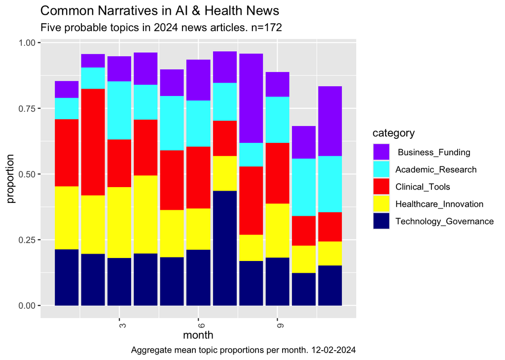

```r
ggplot(vizDataFrame, aes(x=month, y=value, fill=category)) +
  geom_bar(stat = "identity") + ylab("proportion") +
  scale_fill_manual(values = paste0(alphabet(20), "FF"), name = "month") +
  theme(axis.text.x = element_text(angle = 90, hjust = 1)) +
   scale_fill_manual(values=c("#9933FF",
                              "#33FFFF",
                              "red",
                              "yellow",
                              "darkblue",
                              "green"))+
   #                           "blue"))+
   #                           #"pink",
   #                           #"gray",
   #                           #"orange")) +
  labs(title = "Common Narratives in AI & Health News",
       subtitle = "Five probable topics in 2024 news articles. n=172",
       caption = "Aggregate mean topic proportions per month. 12-02-2024")
```

```r
# ggsave(here::here("../lynching_press/output_images_tables/Article_Images/Figure_15_white_topics_oct_19_2024.png"),device = "png",width=9,height=6, dpi=800)
```

## Run a sentiment analysis using the Afinn lexicon

```r
library(tidytext)
#load("afinn.rda")
get_sentiments("afinn")
```

```
## # A tibble: 2,477 × 2
##    word       value
##    <chr>      <dbl>
##  1 abandon       -2
##  2 abandoned     -2
##  3 abandons      -2
##  4 abducted      -2
##  5 abduction     -2
##  6 abductions    -2
##  7 abhor         -3
##  8 abhorred      -3
##  9 abhorrent     -3
## 10 abhors        -3
## # ℹ 2,467 more rows
```

```r
#Tokenize the data, remove stop words
data_tok_mono <- data_tok %>%
  tidytext::unnest_tokens(word,data_use)
View(data_tok_mono) # Tokenize, and create the dateframe of one word per row

# remove stop words
data_tok_mono_filtered <- data_tok_mono  %>%
  filter(!word %in% stop_words$word) %>%
  filter(!is.na(word)) # I removed NA anyways.
View(data_tok_mono_filtered)
#data_tok_mono_filtered

# Generally speaking:
afinn <- data_tok_mono_filtered  %>%
  inner_join(get_sentiments("afinn")) %>%
  summarise(sentiment = sum(value)) %>%
  mutate(method = "AFINN")
afinn
```

```
## # A tibble: 1 × 2
##   sentiment method
##       <dbl> <chr>
## 1      3681 AFINN
```

```r
#The sum of afinn sentiment of the tokenized words is 3681. Since 3681 is way higher than 0, these articles, generally speaking, holding positive emotions when they are covering AI & Health.
```

```r
# Let's see how each article reported it:
# Grouped by articles
article_grouped_data <- articles_df %>%
  group_by(filename) %>%         # Tokenize it by articles
  unnest_tokens(word, text)
article_grouped_data
```

```
## # A tibble: 136,306 × 2
## # Groups:   filename [171]
##    filename           word
##    <chr>              <chr>
##  1 AI_extracted_1.txt this
##  2 AI_extracted_1.txt new
##  3 AI_extracted_1.txt program
##  4 AI_extracted_1.txt builds
##  5 AI_extracted_1.txt on
##  6 AI_extracted_1.txt the
##  7 AI_extracted_1.txt success
##  8 AI_extracted_1.txt of
##  9 AI_extracted_1.txt techstars
## 10 AI_extracted_1.txt equitech
## # ℹ 136,296 more rows
```

```r
# remove stop words
article_grouped_data_filtered <- article_grouped_data %>%
  filter(!word %in% stop_words$word) %>%
  filter(!is.na(word)) # I removed NA anyways.
article_grouped_data_filtered
```

```
## # A tibble: 67,608 × 2
## # Groups:   filename [171]
##    filename           word
##    <chr>              <chr>
##  1 AI_extracted_1.txt program
##  2 AI_extracted_1.txt builds
##  3 AI_extracted_1.txt success
##  4 AI_extracted_1.txt techstars
##  5 AI_extracted_1.txt equitech
##  6 AI_extracted_1.txt cohort
##  7 AI_extracted_1.txt series
##  8 AI_extracted_1.txt partnership
##  9 AI_extracted_1.txt upsurge
## 10 AI_extracted_1.txt baltimore
## # ℹ 67,598 more rows
```

```r
# Now, we calculate the sentiments by articles
sentiment_art <- article_grouped_data_filtered  %>%
  inner_join(get_sentiments("afinn")) %>%
  group_by(filename) %>%
  summarise(sentiment = sum(value))
sentiment_art # Here we go!
```

```
## # A tibble: 163 × 2
##    filename             sentiment
##    <chr>                    <dbl>
##  1 AI_extracted_1.txt          16
##  2 AI_extracted_10.txt         13
##  3 AI_extracted_100.txt        59
##  4 AI_extracted_101.txt         9
##  5 AI_extracted_102.txt        57
##  6 AI_extracted_103.txt         4
##  7 AI_extracted_104.txt         4
##  8 AI_extracted_107.txt       -19
##  9 AI_extracted_108.txt         1
## 10 AI_extracted_109.txt        31
## # ℹ 153 more rows
```

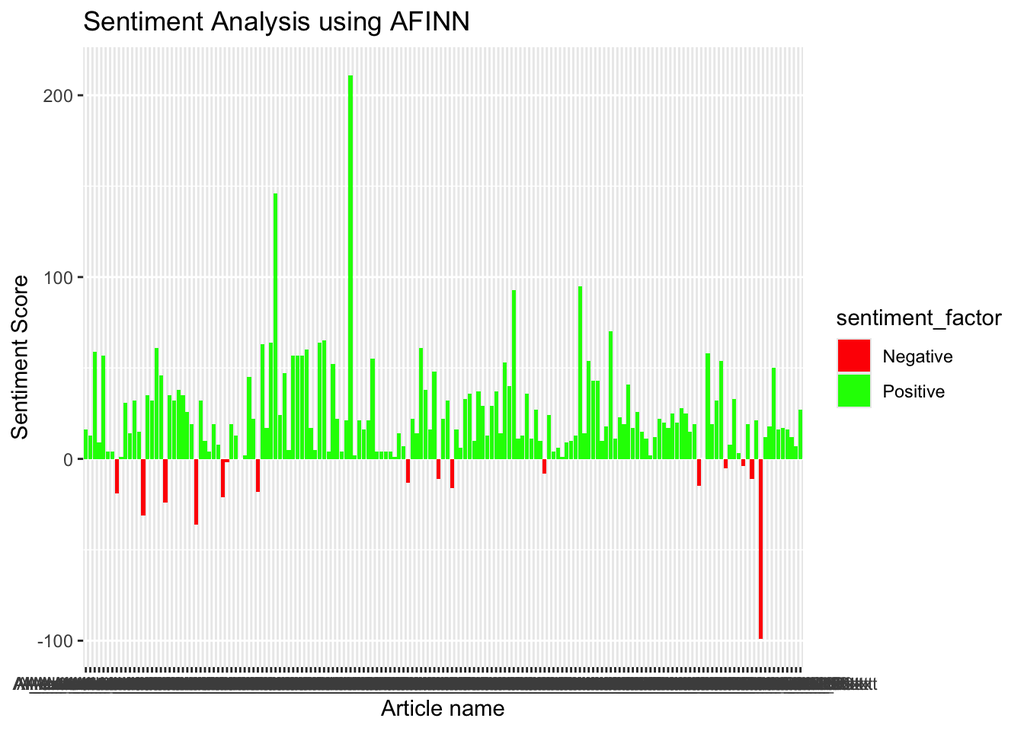

```r
# Plot sentiment over the articles
sentiment_art$sentiment_factor <- cut(sentiment_art$sentiment,
                                      breaks = c(-Inf, 0, Inf),
                                      labels = c("Negative", "Positive"))

ggplot(sentiment_art , aes(x = filename, y = sentiment, fill = sentiment_factor)) +
  geom_col() +
  scale_fill_manual(values = c("Negative" = "red", "Positive" = "green")) +
  labs(title = "Sentiment Analysis using AFINN",
       x = "Article name",
       y = "Sentiment Score")
```

```r
# Let's see how sentiments shift as time goes on.
# Grouped by month
month_grouped_data <- articles_df %>%
  group_by(month) %>%         # Tokenize it by months
  unnest_tokens(word, text)
month_grouped_data
```

```
## # A tibble: 136,306 × 2
## # Groups:   month [11]
##    month word
##    <dbl> <chr>
##  1     8 this
##  2     8 new
##  3     8 program
##  4     8 builds
##  5     8 on
##  6     8 the
##  7     8 success
##  8     8 of
##  9     8 techstars
## 10     8 equitech
## # ℹ 136,296 more rows
```

```r
# remove stop words
month_grouped_data_filtered <- month_grouped_data %>%
  filter(!word %in% stop_words$word) %>%
  filter(!is.na(word)) # I removed NA anyways.
month_grouped_data_filtered
```

```
## # A tibble: 67,608 × 2
## # Groups:   month [11]
##    month word
##    <dbl> <chr>
##  1     8 program
##  2     8 builds
##  3     8 success
##  4     8 techstars
##  5     8 equitech
##  6     8 cohort
##  7     8 series
##  8     8 partnership
##  9     8 upsurge
## 10     8 baltimore
## # ℹ 67,598 more rows
```

```r
# Now, we calculate the sentiments by articles
month_sentiment_art <- month_grouped_data_filtered  %>%
  inner_join(get_sentiments("afinn")) %>%
  group_by(month) %>%
  summarise(sentiment = sum(value))
month_sentiment_art # Here we go!
```

```
## # A tibble: 11 × 2
##    month sentiment
##    <dbl>     <dbl>
##  1     1       302
##  2     2       216
##  3     3       504
##  4     4       418
##  5     5       230
##  6     6       310
##  7     7       411
##  8     8       287
##  9     9       151
## 10    10       593
## 11    11       259
```

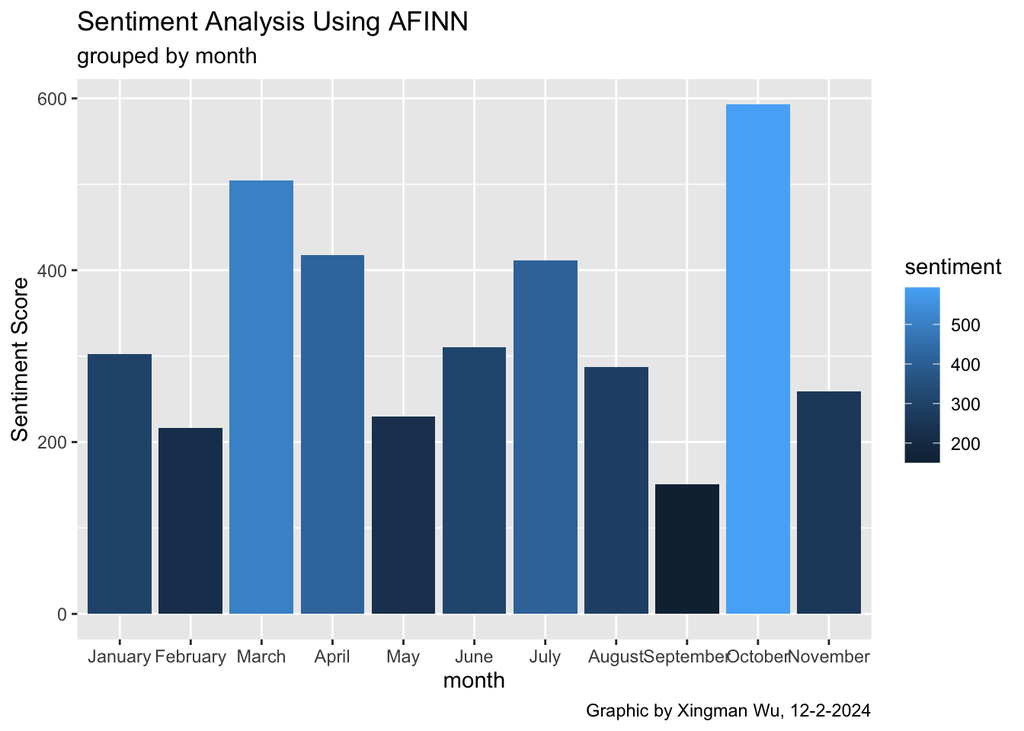

```r
month_sentiment_art$month <- factor(month_sentiment_art$month, levels = 1:12, labels = month.name)

# Plot sentiment over the articles
ggplot(month_sentiment_art, aes(x = month, y = sentiment, fill = sentiment)) +
  geom_col(position = "dodge") +
  labs(title = "Sentiment Analysis Using AFINN",
       subtitle = "grouped by month",
      caption = "Graphic by Xingman Wu, 12-2-2024",
       x = "month",
       y = "Sentiment Score")
```

## To be continue…

I will take a closer look into the content and try to 1) explain the reasons why sentiments varied; 2) what are the negative sentiments about. Additionally, I will give co-occurrence analysis a chance.